# How Do Socio-Economic Factors Influence Global Life Expectancy?

An Exploratory Data Analysis

## Project Overview

This project explores the relationship between global life expectancy and socio-economic indicators from 2000 to 2019. Using World Bank data, I focus on understanding how a country’s wealth, education, and health investments relate to population health outcomes.

**Research Question:**

How have life expectancy trends evolved globally over the last two decades, and which socio-economic factors are most strongly associated with these trends?

## Dataset

**Source:** [Kaggle – “Life Expectancy & Socio-Economic Factors” (World Bank)](https://www.kaggle.com/datasets/mjshri23/life-expectancy-and-socio-economic-world-bank)

**All Relevant Variables:**

| Variable | Description |
| --- | --- |
| **Country.Name** | Name of the country. |
| **Country.Code** | country code. |
| **Region** | Geographical region classification. |
| **IncomeGroup** | I ncome classification (Low, Lower Middle, Upper Middle, High). |
| **Year** | Observation year (2000–2019). |
| **Life.Expectancy.World.Bank** | Average life expectancy at birth, reported by the World Bank. |
| **Health.Expenditure..** | Current health expenditure as a percentage of GDP. Represents spending on healthcare services and goods consumed within the year. |
| **Education.Expenditure..** | Total government expenditure on education as a percentage of GDP. Includes current and capital spending. |
| **Prevelance.of.Undernourishment** | Percentage of the population not consuming enough calories for an active, healthy life. |
| **CO2** | CO2 emissions per capita (metric tons). A general indicator of industrialization and economic activity. |
| **Unemployment** | Percentage of the total labor force that is unemployed but actively seeking work. |
| **Corruption** | CPIA transparency and accountability rating, measuring public sector governance quality. |
| **Sanitation** | Percentage of the population using safely managed sanitation services. |
| **Injuries** | Disability-Adjusted Life Years (DALYs) lost due to injuries. Higher values indicate worse injury-related health outcomes. |
| **Communicable** | DALYs from communicable diseases. Reflects the burden of infectious disease. |
| **NonCommunicable** | DALYs from noncommunicable diseases. Higher values indicate greater chronic illness burden. |

**Data Cleaning**

- Load dataset

```r
# Load dataset
raw_data <- read.csv("life expectancy.csv", header = TRUE)

# Make a copy of the dataset for cleaning
clean_data <- raw_data
```

- Standardize column names

```r
names(clean_data) <- make.names(names(clean_data), unique = TRUE)
```

- Remove duplicates and empty strings

```r
clean_data <- clean_data |> distinct()

clean_data <- clean_data |>
mutate(across(where(is.character), ~na_if(., ""))) |>
mutate(across(where(is.character), trimws))
```

- Convert numeric-looking strings to numeric

```r
clean_data <- clean_data |>
mutate(across(where(function(x) all(grepl("^[0-9.]+$", x[!is.na(x)]))), as.numeric))
```

- Filter years 2000–2019

```r
if ("Year" %in% names(clean_data)) {
clean_data <- clean_data |> filter(Year >= 2000, Year <= 2019)
}
```

```r
if ("Life.expectancy" %in% names(clean_data)) {
clean_data <- clean_data |> drop_na(Life.expectancy)
}
```

- Save cleaned dataset as `cleaned_life_expectancy.csv`

```r
write.csv(clean_data, "cleaned_life_expectancy.csv", row.names = FALSE)
cat("File saved: cleaned_life_expectancy.csv\n")
```

```
## File saved: cleaned_life_expectancy.csv
```

## Exploring the Data

Get the dimensions (rows and columns)

```r
dim(clean_data)
```

```
## [1] 3306   16
```

View first few rows

```r
head(clean_data)
```

```
##           Country.Name Country.Code                     Region
## 1          Afghanistan          AFG                 South Asia
## 2               Angola          AGO         Sub-Saharan Africa
## 3              Albania          ALB      Europe & Central Asia
## 4              Andorra          AND      Europe & Central Asia
## 5 United Arab Emirates          ARE Middle East & North Africa
## 6            Argentina          ARG  Latin America & Caribbean
##           IncomeGroup Year Life.Expectancy.World.Bank
## 1          Low income 2001                     56.308
## 2 Lower middle income 2001                     47.059
## 3 Upper middle income 2001                     74.288
## 4         High income 2001                         NA
## 5         High income 2001                     74.544
## 6 Upper middle income 2001                     73.755
##   Prevelance.of.Undernourishment    CO2 Health.Expenditure..
```

[output cut: 20 more lines]

View column names

```r
colnames(clean_data)
```

```
##  [1] "Country.Name"                   "Country.Code"
##  [3] "Region"                         "IncomeGroup"
##  [5] "Year"                           "Life.Expectancy.World.Bank"
##  [7] "Prevelance.of.Undernourishment" "CO2"
##  [9] "Health.Expenditure.."           "Education.Expenditure.."
## [11] "Unemployment"                   "Corruption"
## [13] "Sanitation"                     "Injuries"
## [15] "Communicable"                   "NonCommunicable"
```

View data structures and types

```r
str(clean_data)
```

```
## 'data.frame':    3306 obs. of  16 variables:
##  $ Country.Name                  : chr  "Afghanistan" "Angola" "Albania" "Andorra" ...
##  $ Country.Code                  : chr  "AFG" "AGO" "ALB" "AND" ...
##  $ Region                        : chr  "South Asia" "Sub-Saharan Africa" "Europe & Central Asia" "Europe & Central Asia" ...
##  $ IncomeGroup                   : chr  "Low income" "Lower middle income" "Upper middle income" "High income" ...
##  $ Year                          : num  2001 2001 2001 2001 2001 ...
##  $ Life.Expectancy.World.Bank    : num  56.3 47.1 74.3 NA 74.5 ...
##  $ Prevelance.of.Undernourishment: num  47.8 67.5 4.9 NA 2.8 3 26.1 NA NA 2.5 ...
##  $ CO2                           : num  730 15960 3230 520 97200 ...
##  $ Health.Expenditure..          : num  NA 4.48 7.14 5.87 2.48 ...
##  $ Education.Expenditure..       : num  NA NA 3.46 NA NA ...
##  $ Unemployment                  : num  10.81 4 18.58 NA 2.49 ...
##  $ Corruption                    : num  NA NA NA NA NA NA NA NA NA NA ...
##  $ Sanitation                    : num  NA NA 40.5 21.8 NA ...
##  $ Injuries                      : num  2179727 1392081 117082 1698 144678 ...
##  $ Communicable                  : num  9689194 11190211 140895 696 65272 ...
##  $ NonCommunicable               : num  5795426 2663516 532325 13637 481741 ...
```

## Descriptive Statistics

```r
numeric_cols <- clean_data |> select(where(is.numeric))
summary(numeric_cols)
```

```
##       Year      Life.Expectancy.World.Bank Prevelance.of.Undernourishment
##  Min.   :2001   Min.   :40.37              Min.   : 2.50
##  1st Qu.:2005   1st Qu.:63.64              1st Qu.: 2.50
##  Median :2010   Median :72.17              Median : 6.20
##  Mean   :2010   Mean   :69.75              Mean   :10.66
##  3rd Qu.:2015   3rd Qu.:76.81              3rd Qu.:14.78
##  Max.   :2019   Max.   :84.36              Max.   :70.90
##                 NA's   :188                NA's   :684
##       CO2           Health.Expenditure.. Education.Expenditure..
##  Min.   :      10   Min.   : 1.264       Min.   : 0.8503
##  1st Qu.:    2002   1st Qu.: 4.205       1st Qu.: 3.1361
##  Median :   10205   Median : 5.892       Median : 4.3715
##  Mean   :  157492   Mean   : 6.364       Mean   : 4.5890
##  3rd Qu.:   58773   3rd Qu.: 8.119       3rd Qu.: 5.5198
##  Max.   :10707220   Max.   :24.231       Max.   :23.2700
##  NA's   :152        NA's   :180          NA's   :1090
##   Unemployment      Corruption      Sanitation         Injuries
##  Min.   : 0.100   Min.   :1.000   Min.   :  2.378   Min.   :     430
##  1st Qu.: 3.733   1st Qu.:2.500   1st Qu.: 24.746   1st Qu.:   62457
##  Median : 5.920   Median :3.000   Median : 49.317   Median :  245691
##  Mean   : 7.891   Mean   :2.861   Mean   : 52.739   Mean   : 1318219
##  3rd Qu.:10.098   3rd Qu.:3.250   3rd Qu.: 80.279   3rd Qu.:  846559
##  Max.   :37.250   Max.   :4.500   Max.   :100.000   Max.   :55636759
##  NA's   :304      NA's   :2331    NA's   :1247
##   Communicable       NonCommunicable
##  Min.   :      330   Min.   :     2482
##  1st Qu.:    57765   1st Qu.:   318476
##  Median :   314769   Median :  1350146
##  Mean   :  4686289   Mean   :  7392488
##  3rd Qu.:  2831636   3rd Qu.:  3918468
##  Max.   :268564610   Max.   :324637810
##
```

## Variable Selection

Although the dataset contains additional variables (CO2 emissions, unemployment rates, disease spread, corruption ratings), this analysis focuses on the variables most directly tied to life expectancy:

1. health spending
2. education spending
3. income level

Other variables are listed as potentially related but not explored in depth due to the project scope.

## Potential Relationships We Expect

1. Life expectancy increases over time
2. Higher health expenditure likely -> higher life expectancy
3. Higher education expenditure -> higher life expectancy
4. Higher income group -> higher life expectancy

### 1. How Has Global Life Expectancy Evolved Over Time?

- **Visualization:** Line plot of average life expectancy between 2000 and 2019.

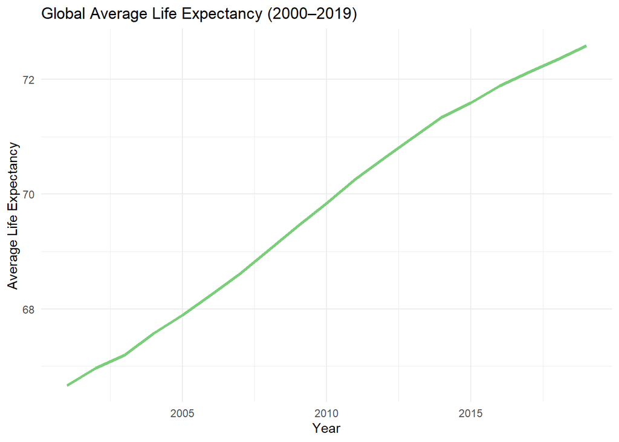

```r
clean_data |>
  group_by(Year) |>
  summarize(mean_life = mean(Life.Expectancy.World.Bank, na.rm = TRUE)) |>
  ggplot(aes(x = Year, y = mean_life)) +
  geom_line(linewidth = 1.2, color = "palegreen3") +
  labs(
    title = "Global Average Life Expectancy (2000–2019)",
    x = "Year",
    y = "Average Life Expectancy"
  ) +
  theme_minimal()
```

### 2. How Does Health Expenditure Influence Life Expectancy?

- **Visualization:** Scatterplot with regression line.

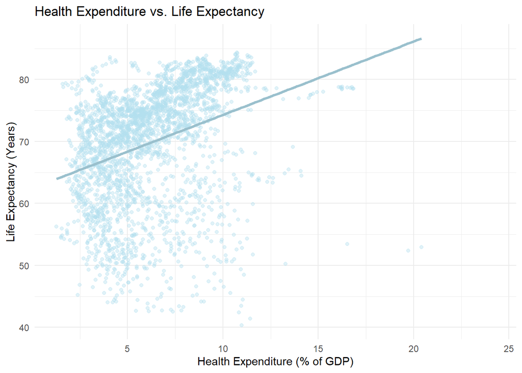

```r
clean_data |>
  ggplot(aes(x = Health.Expenditure.., y = Life.Expectancy.World.Bank)) +
  geom_point(alpha = 0.4, color = "lightblue2") +
  geom_smooth(method = "lm", se = FALSE, linewidth = 1.2, color = "lightblue3") +
  labs(
    title = "Health Expenditure vs. Life Expectancy",
    x = "Health Expenditure (% of GDP)",
    y = "Life Expectancy (Years)"
  ) +
  theme_minimal()
```

- **Insight:** Countries with higher health expenditure tend to have higher life expectancy. The positive regression line implies that wealthier nations generally provide better healthcare, nutrition, and infrastructure. However, the scatter plot includes numerous outliers so we cannot say for sure that there is a direct correlation without considering other factors.

### 3. How Does Education Expenditure Influence Life Expectancy?

- **Visualization:** Scatterplot with regression line.

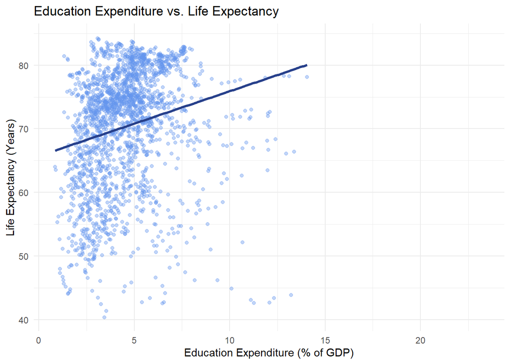

```r
clean_data |>
  ggplot(aes(x = Education.Expenditure..,
             y = Life.Expectancy.World.Bank)) +
  geom_point(alpha = 0.4, color = "cornflowerblue") +
  geom_smooth(method = "lm", se = FALSE, linewidth = 1.2, color = "royalblue4") +
  labs(
    title = "Education Expenditure vs. Life Expectancy",
    x = "Education Expenditure (% of GDP)",
    y = "Life Expectancy (Years)"
  ) +
  theme_minimal()
```

- **Insight:** Higher education expenditure is associated with higher life expectancy, but the relationship is typically weaker and more variable than health expenditure. This makes sense because investing in education indirectly supports health by improving health literacy, economic opportunities, and long-term outcomes, but the effect is not as direct as healthcare investments.

### 4. How Does Life Expectancy Differ By Income Group?

- **Visualization:** Boxplot grouped by income classification.

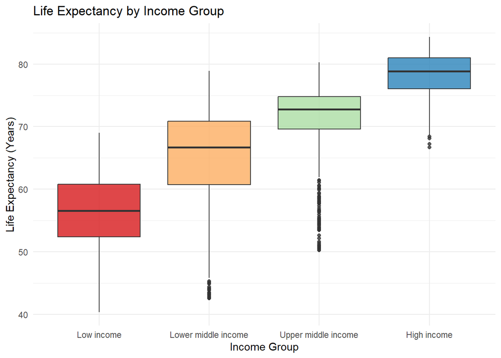

```r
clean_data$IncomeGroup <- factor(
  clean_data$IncomeGroup,
  levels = c("Low income", "Lower middle income", "Upper middle income", "High income")
)

clean_data |>
  ggplot(aes(
    x = IncomeGroup,
    y = Life.Expectancy.World.Bank,
    fill = IncomeGroup
  )) +
  geom_boxplot(alpha = 0.8) +
  labs(
    title = "Life Expectancy by Income Group",
    x = "Income Group",
    y = "Life Expectancy (Years)"
  ) +
  theme_minimal() +
  theme(legend.position = "none") +
  scale_fill_brewer(palette = "Spectral")
```

- **Insight:** Life expectancy increases clearly across income groups, with high-income countries showing the highest median values and low-income countries showing the lowest. The separation between groups highlights persistent global health inequalities tied to resources, infrastructure, and access to medical care. Variation within groups suggests that income level is important but not the only factor influencing population health.

## Data Limitations

- Dataset focuses on national-level data, not individual-level outcomes
- Regional differences within countries are not captured
- Some socio-economic indicators (ex. CO2 emissions, corruption) were omitted to simplify analysis
- Missing data and small variations in reporting may bias results

*GitHub Repository:* https://github.com/SNazari23/INST447_Group_Project/tree/mainSNazari23